# In-Class: September 19, 2018

## Part 1 (You can do this with or without dplyr)

1. The data set at rnf6080.dat records hourly rainfall at a certain location in Canada, every day from 1960 to 1980. First, we need to load the data set into R using the command read.table(). Use the help function to learn what arguments this function takes. Once you have the necessary input, load the data set into R and make it a data frame called rain.df.

```r
#This line creates a new data frame called rain.df that takes in the data from the "rnf6080.dat" file.
rain.df <- read.table("rnf6080.dat")
```

2. How many rows and columns does rain.df have? (If there are not 5070 rows and 27 columns, something is wrong; check the previous part to see what might have gone wrong in the previous part.)

```r
#The function dim tells you how many rows and columns you have, we use it on the rain.df data frame to see its size.
dim(rain.df)
```

```
## [1] 5070   27
```

3. What are the names of the columns of rain.df?

```r
#The names function tells you have the names of a column of a data frame.
names(rain.df)
```

```
##  [1] "V1"  "V2"  "V3"  "V4"  "V5"  "V6"  "V7"  "V8"  "V9"  "V10" "V11"
## [12] "V12" "V13" "V14" "V15" "V16" "V17" "V18" "V19" "V20" "V21" "V22"
## [23] "V23" "V24" "V25" "V26" "V27"
```

4. What is the value of row 5, column 7 of rain.df?

```r
#Calling the name of a data frame with the indices you are interested in will display that entry:
rain.df[5,7]
```

```
## [1] 0
```

5. Display the second row of rain.df in its entirety.

```r
#If you are interested in an entire row of a data frame, just leave the column index blank:
rain.df[2, ]
```

```
##   V1 V2 V3 V4 V5 V6 V7 V8 V9 V10 V11 V12 V13 V14 V15 V16 V17 V18 V19 V20
## 2 60  4  2  0  0  0  0  0  0   0   0   0   0   0   0   0   0   0   0   0
##   V21 V22 V23 V24 V25 V26 V27
## 2   0   0   0   0   0   0   0
```

6. Explain what the command below doesby running it on your data and examining the object. (You may find the display functions head() and tail() useful here.) Is it clear now what the last 24 columns represent?

```r
names(rain.df) <- c("year","month","day",seq(0,23))
#This bit of code gives names to the columns, making it clear that the first three columns give the date of the measurement taken. The next 24 columns tell you the amount of rainfall in each of those hours.
```

7. Create a new column in the data frame called daily, which is the sum of the rightmost 24 columns. With this column, create a histogram of the values in this column, which are supposed to be daily rainfall values. What is wrong with this picture?

```r
#We load the dplyr library to use some of its functions for data manipulation.
library(dplyr)
```

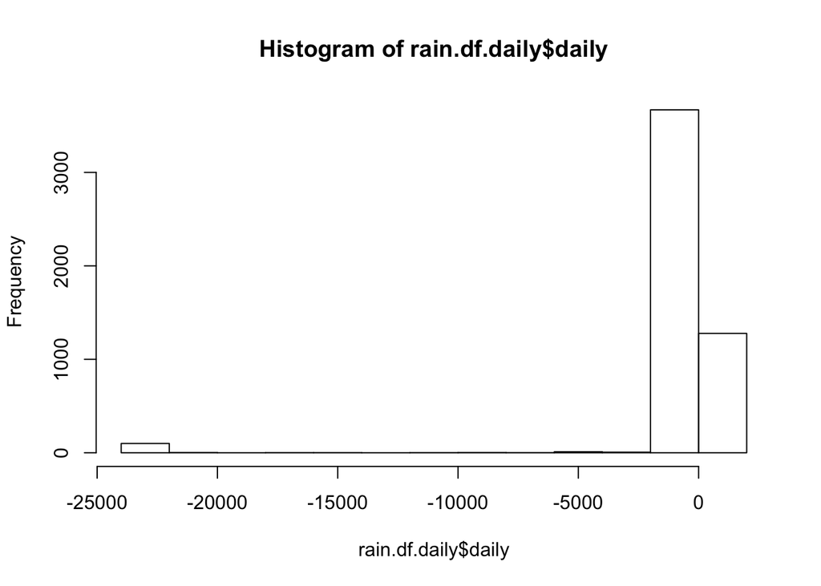

```r
#The mutate function adds a new column from some function of the existing data, it's used to calculate the sum of the hourly rainfall to get a daily rainfall value.
rain.df.daily <- mutate(rain.df, daily = rowSums(rain.df[,4:27]))
#Then a histogram is made of the daily rain values.
hist(rain.df.daily$daily)
```

```r
#There are large negative numbers in the histogram, which obviously does not make sense for daily rainfall.
```

8. Create a new data frame rain.df.fixed that takes the original and fixes it for the apparent flaw you have discovered. Having done this, produce a new histogram with the corrected data and explain why this is more reasonable.

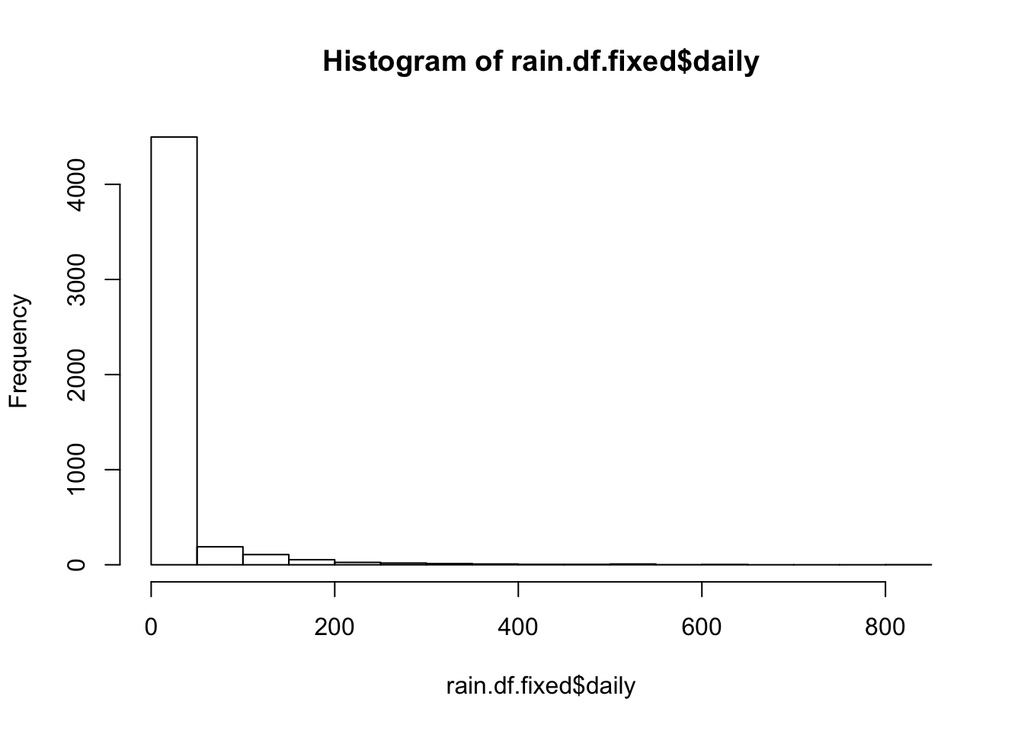

```r
#Some of the data entries are -999, which means that the data was not acquired for some reason - these will be changed to NAs.
rain.df.daily[rain.df.daily < 0] = NA
rain.df.fixed <- rain.df.daily
#Now we reproduce the histogram.
hist(rain.df.fixed$daily)
```

```r
#This histogram makes more since, most of the days have little or no rainfall, with some days having larger amounts of rain.
```

## Part 2

### New York City Flights 13

```r
library(nycflights13)
```

```r
library(dplyr)
library(ggplot2)
flights
```

```
## # A tibble: 336,776 x 19
##     year month   day dep_time sched_dep_time dep_delay arr_time
##    <int> <int> <int>    <int>          <int>     <dbl>    <int>
##  1  2013     1     1      517            515      2.00      830
##  2  2013     1     1      533            529      4.00      850
##  3  2013     1     1      542            540      2.00      923
##  4  2013     1     1      544            545     -1.00     1004
##  5  2013     1     1      554            600     -6.00      812
##  6  2013     1     1      554            558     -4.00      740
##  7  2013     1     1      555            600     -5.00      913
##  8  2013     1     1      557            600     -3.00      709
##  9  2013     1     1      557            600     -3.00      838
## 10  2013     1     1      558            600     -2.00      753
## # ... with 336,766 more rows, and 12 more variables: sched_arr_time <int>,
## #   arr_delay <dbl>, carrier <chr>, flight <int>, tailnum <chr>,
## #   origin <chr>, dest <chr>, air_time <dbl>, distance <dbl>, hour <dbl>,
## #   minute <dbl>, time_hour <dttm>
```

### Basic Dplyr

The `dplyr` package uses verbs to perform data manipulation.

- `filter()` and `slice()`
- `arrange()`
- `select()` and `rename()`
- `distinct()`
- `mutate()` and `transmute()`
- `sample_n()` and `sample_frac()`

### Filtering Rows

1. Filter all flights on your birthday.

```r
#My birthday is April 4th, so I filter for that date in the flights tbl.
filter(flights, month == 4 & day == 4)
```

```
## # A tibble: 985 x 19
##     year month   day dep_time sched_dep_time dep_delay arr_time
##    <int> <int> <int>    <int>          <int>     <dbl>    <int>
##  1  2013     4     4       14           2245     89.0       124
##  2  2013     4     4      454            500    - 6.00      636
##  3  2013     4     4      511            515    - 4.00      808
##  4  2013     4     4      529            530    - 1.00      829
##  5  2013     4     4      538            540    - 2.00      847
##  6  2013     4     4      542            545    - 3.00      904
##  7  2013     4     4      544            545    - 1.00      913
##  8  2013     4     4      550            600    -10.0       900
##  9  2013     4     4      551            600    - 9.00      838
## 10  2013     4     4      552            600    - 8.00      703
## # ... with 975 more rows, and 12 more variables: sched_arr_time <int>,
## #   arr_delay <dbl>, carrier <chr>, flight <int>, tailnum <chr>,
## #   origin <chr>, dest <chr>, air_time <dbl>, distance <dbl>, hour <dbl>,
## #   minute <dbl>, time_hour <dttm>
```

2. Filter all flights in rows 567 - 589

```r
#We don't need to use the dplyr function filter to select a set of rows.
flights[567:589, ]
```

```
## # A tibble: 23 x 19
##     year month   day dep_time sched_dep_time dep_delay arr_time
##    <int> <int> <int>    <int>          <int>     <dbl>    <int>
##  1  2013     1     1     1653           1700    - 7.00     2005
##  2  2013     1     1     1654           1644     10.0      1752
##  3  2013     1     1     1654           1700    - 6.00     2020
##  4  2013     1     1     1655           1621     34.0      1804
##  5  2013     1     1     1655           1700    - 5.00     1953
##  6  2013     1     1     1655           1700    - 5.00     2027
##  7  2013     1     1     1655           1655      0        2025
##  8  2013     1     1     1656           1700    - 4.00     1941
##  9  2013     1     1     1657           1650      7.00     1921
## 10  2013     1     1     1657           1630     27.0      1948
## # ... with 13 more rows, and 12 more variables: sched_arr_time <int>,
## #   arr_delay <dbl>, carrier <chr>, flight <int>, tailnum <chr>,
## #   origin <chr>, dest <chr>, air_time <dbl>, distance <dbl>, hour <dbl>,
## #   minute <dbl>, time_hour <dttm>
```

### Arranging Rows

3. Use arrange() to order the data by year, month and day

```r
#This uses the dplyr function arrange to sort the data by year, month and day.
arrange(flights, year, month, day)
```

```
## # A tibble: 336,776 x 19
##     year month   day dep_time sched_dep_time dep_delay arr_time
##    <int> <int> <int>    <int>          <int>     <dbl>    <int>
##  1  2013     1     1      517            515      2.00      830
##  2  2013     1     1      533            529      4.00      850
##  3  2013     1     1      542            540      2.00      923
##  4  2013     1     1      544            545     -1.00     1004
##  5  2013     1     1      554            600     -6.00      812
##  6  2013     1     1      554            558     -4.00      740
##  7  2013     1     1      555            600     -5.00      913
##  8  2013     1     1      557            600     -3.00      709
##  9  2013     1     1      557            600     -3.00      838
## 10  2013     1     1      558            600     -2.00      753
## # ... with 336,766 more rows, and 12 more variables: sched_arr_time <int>,
## #   arr_delay <dbl>, carrier <chr>, flight <int>, tailnum <chr>,
## #   origin <chr>, dest <chr>, air_time <dbl>, distance <dbl>, hour <dbl>,
## #   minute <dbl>, time_hour <dttm>
```

4. Use desc() to arrange flights by arrival delay.

```r
#Adding desc() to the argument of arrange will sort the data in descending order (ascending is the default). The data is then sorted by arrival delay in descending order.
arrange(flights, desc(arr_delay))
```

```
## # A tibble: 336,776 x 19
##     year month   day dep_time sched_dep_time dep_delay arr_time
##    <int> <int> <int>    <int>          <int>     <dbl>    <int>
##  1  2013     1     9      641            900      1301     1242
##  2  2013     6    15     1432           1935      1137     1607
##  3  2013     1    10     1121           1635      1126     1239
##  4  2013     9    20     1139           1845      1014     1457
##  5  2013     7    22      845           1600      1005     1044
##  6  2013     4    10     1100           1900       960     1342
##  7  2013     3    17     2321            810       911      135
##  8  2013     7    22     2257            759       898      121
##  9  2013    12     5      756           1700       896     1058
## 10  2013     5     3     1133           2055       878     1250
## # ... with 336,766 more rows, and 12 more variables: sched_arr_time <int>,
## #   arr_delay <dbl>, carrier <chr>, flight <int>, tailnum <chr>,
## #   origin <chr>, dest <chr>, air_time <dbl>, distance <dbl>, hour <dbl>,
## #   minute <dbl>, time_hour <dttm>
```

### Select

5. Select columns containing date information.

```r
#This uses the dplyr function select to take out only the columns with date information (year, month, day).
select(flights, year, month, day)
```

```
## # A tibble: 336,776 x 3
##     year month   day
##    <int> <int> <int>
##  1  2013     1     1
##  2  2013     1     1
##  3  2013     1     1
##  4  2013     1     1
##  5  2013     1     1
##  6  2013     1     1
##  7  2013     1     1
##  8  2013     1     1
##  9  2013     1     1
## 10  2013     1     1
## # ... with 336,766 more rows
```

6. Select columns including only plane information.

```r
#Again, this uses the select function to take out the columns with plane information (carrier, tailnum)
select(flights, carrier, tailnum)
```

```
## # A tibble: 336,776 x 2
##    carrier tailnum
##    <chr>   <chr>
##  1 UA      N14228
##  2 UA      N24211
##  3 AA      N619AA
##  4 B6      N804JB
##  5 DL      N668DN
##  6 UA      N39463
##  7 B6      N516JB
##  8 EV      N829AS
##  9 B6      N593JB
## 10 AA      N3ALAA
## # ... with 336,766 more rows
```

7. Rename tailnum to tail_num

```r
#The rename function can change the column named "tailnum" to "tail_num", note the new name goes first in the second argument of the function.
flights <- rename(flights, tail_num = tailnum)
```

### Mutating Rows

8. Create a variable called gain which describes the difference between arrival delap and departure delay.

```r
#The mutate function can add new columns to a table that use data from existing columns. This can be used to add a new column "gain" which is the difference of arrival delay and departure delay.
mutate(flights, gain = arr_delay - dep_delay)
```

```
## # A tibble: 336,776 x 20
##     year month   day dep_time sched_dep_time dep_delay arr_time
##    <int> <int> <int>    <int>          <int>     <dbl>    <int>
##  1  2013     1     1      517            515      2.00      830
##  2  2013     1     1      533            529      4.00      850
##  3  2013     1     1      542            540      2.00      923
##  4  2013     1     1      544            545     -1.00     1004
##  5  2013     1     1      554            600     -6.00      812
##  6  2013     1     1      554            558     -4.00      740
##  7  2013     1     1      555            600     -5.00      913
##  8  2013     1     1      557            600     -3.00      709
##  9  2013     1     1      557            600     -3.00      838
## 10  2013     1     1      558            600     -2.00      753
## # ... with 336,766 more rows, and 13 more variables: sched_arr_time <int>,
## #   arr_delay <dbl>, carrier <chr>, flight <int>, tail_num <chr>,
## #   origin <chr>, dest <chr>, air_time <dbl>, distance <dbl>, hour <dbl>,
## #   minute <dbl>, time_hour <dttm>, gain <dbl>
```

9. Create a variable called speed which is distance over time in hours.

```r
#The mutate function is used again to add a speed variable to the tbl.
mutate(flights, speed = distance/(air_time/60))
```

```
## # A tibble: 336,776 x 20
##     year month   day dep_time sched_dep_time dep_delay arr_time
##    <int> <int> <int>    <int>          <int>     <dbl>    <int>
##  1  2013     1     1      517            515      2.00      830
##  2  2013     1     1      533            529      4.00      850
##  3  2013     1     1      542            540      2.00      923
##  4  2013     1     1      544            545     -1.00     1004
##  5  2013     1     1      554            600     -6.00      812
##  6  2013     1     1      554            558     -4.00      740
##  7  2013     1     1      555            600     -5.00      913
##  8  2013     1     1      557            600     -3.00      709
##  9  2013     1     1      557            600     -3.00      838
## 10  2013     1     1      558            600     -2.00      753
## # ... with 336,766 more rows, and 13 more variables: sched_arr_time <int>,
## #   arr_delay <dbl>, carrier <chr>, flight <int>, tail_num <chr>,
## #   origin <chr>, dest <chr>, air_time <dbl>, distance <dbl>, hour <dbl>,
## #   minute <dbl>, time_hour <dttm>, speed <dbl>
```

### Summarise

10. Summarise the average delay for all flights.

```r
#This summary gives the average arrival delay for all flights, with NA's removed.
summarise(flights, average_delay = mean(arr_delay[!is.na(arr_delay)]))
```

```
## # A tibble: 1 x 1
##   average_delay
##           <dbl>
## 1          6.90
```

## Overall Questions

11. Split the complete dataset into individual planes and then summarise each plane by counting the number of flights (count = n()) and computing the average distance and arrival delay . Then plot this:

```
ggplot(delay, aes(dist, delay)) +
  geom_point(aes(size = count), alpha = 1/2) +
  geom_smooth() +
  scale_size_area()
```

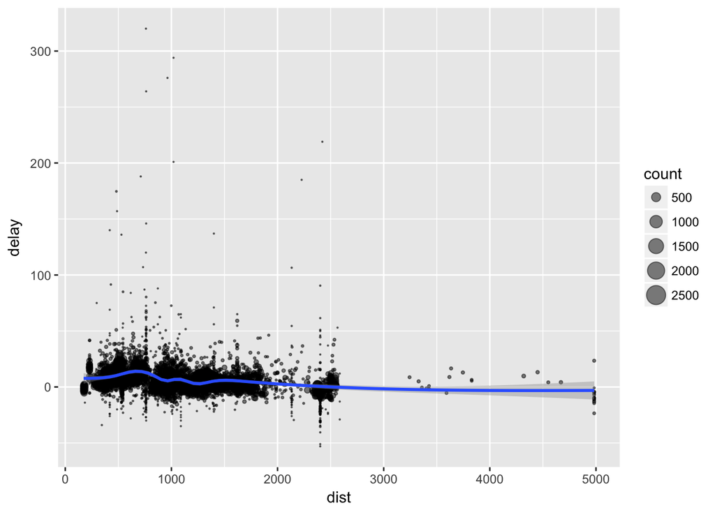

```r
#The group_by function can be used to split the dataset into individual planes (which are distinguished by their tail number). After the planes are grouped, the summarise function can count the number of flights for each plane and their average distance and arrival delay (again the NA's are removed).
delay <- flights %>%
  group_by(tail_num) %>%
    summarise(count = n(), dist = mean(distance[!is.na(distance)]), delay = mean(arr_delay[!is.na(arr_delay)]))

ggplot(delay, aes(dist, delay)) +
  geom_point(aes(size = count), alpha = 1/2) +
  geom_smooth() +
  scale_size_area()
```

```r
#Each individual plane is represented as a dot on the graph, with its average distance travelled plotted against its average delay in arrival. The size of the dot gives an idea of how many flights the plane has made, with a key to the sizes given on the graph.
```

12. Find the number of planes and the number of flights that go to each possible destination.

```r
#First, you have to group by the destination of the flights. Then, to summarise - first the number of planes is equal to the number of distinct tail numbers that go to a particular destination, this can be obtained with the n_distinct function. Finally, the number of flights is just equal to the number of observations for each destination, which can be obtained with the n() function.
flights %>%
  group_by(dest) %>%
    summarise(num_planes = n_distinct(tail_num), num_flights = n())
```

```
## # A tibble: 105 x 3
##    dest  num_planes num_flights
##    <chr>      <int>       <int>
##  1 ABQ          108         254
##  2 ACK           58         265
##  3 ALB          172         439
##  4 ANC            6           8
##  5 ATL         1180       17215
##  6 AUS          993        2439
##  7 AVL          159         275
##  8 BDL          186         443
##  9 BGR           46         375
## 10 BHM           45         297
## # ... with 95 more rows
```